# Relatório de análise de dados - El Niño

# Precipitação

## Dados observados (setembro e outubro)

- Em outubro, 72,0% do território da Amazônia Legal teve chuva abaixo da média, e 20,7% teve anomalia de precipitação abaixo de -50mm. Em setembro, foram 61,5% e 6,5%, respectivamente (Tabela 1)
- Entre as bacias hidrográficas, as com maior parte do território abaixo de -50mm em outubro foram Trombetas/Uatumã (48%), Purus (37%) e Negro (29%); as com menor parte foram Mearim (0%), Gurupi (0%), Itapecuru (0%), Paru/Jari (0%) e Foz do Amazonas (0%). Nessas, a parte do território com chuva abaixo da média foi entre 60% e 100% (Tabela 2)
- Os estados com maior parte do território abaixo de -50mm em outubro foram RR (63%), AC (49%) e RO (38%). Em setembro, foram RR (80%), AM (7%) e PA (3%) (Tabela 3)
- 305 dos 809 municípios da Amazônia Legal tiveram alguma parte do território com anomalia abaixo de -50mm em outubro; em 80 deles, isso valeu para mais da metade do território. Em setembro, foram 62 e 18, respectivamente (Tabela 4)
- Percentual do território com anomalia abaixo de -50mm em outubro nos municípios selecionados: Manicoré (34%), Novo Aripuanã (24%), Humaitá (24%), Nova Olinda do Norte (17%), Manaus (12%) e Borba (7%) (Figura 3)

**Como as anomalias observadas foram calculadas**

As anomalias observadas de precipitação foram fornecidas pelo Labclim, a partir do MERGE (INPE), em grade de 0,1° (cerca de 11 km). A anomalia é a diferença entre a chuva acumulada no mês e a normal de 1998-2024. A Amazônia Legal considerada aqui são os 9 estados inteiros (AC, AM, AP, MA, MT, PA, RO, RR e TO), incluindo todo o Maranhão, e as bacias hidrográficas são as mesorregiões hidrográficas do IBGE com mais da metade da área nesses estados. Cada célula entra no cálculo quando seu centro cai dentro da área analisada, com peso proporcional à sua área. Nos municípios, entram também as células que tocam o contorno, o que pode aumentar um pouco a contagem de municípios pequenos.

Tabela 1: Percentual do território da Amazônia Legal com anomalia de precipitação observada abaixo de 0mm e de -50mm.

| Mês | Anomalia média | <0mm | <-50mm |
| --- | --- | --- | --- |
| setembro | -4,1mm | 61,5% | 6,5% |
| outubro | -15,9mm | 72,0% | 20,7% |

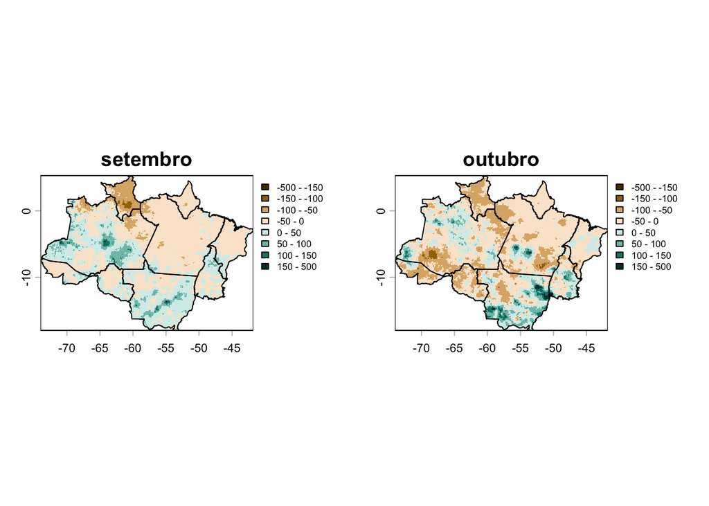

Figura 1: Anomalia de precipitação observada (mm) na Amazônia Legal, setembro e outubro de 2026

Tabela 2: Percentual do território das bacias hidrográficas da Amazônia Legal com anomalia de precipitação observada abaixo de 0mm e de -50mm.

| Bacia | setembro <0mm | setembro <-50mm | outubro <0mm | outubro <-50mm |
| --- | --- | --- | --- | --- |
| Trombetas/Uatumã | 100% | 22% | 98% | 48% |
| Purus | 44% | 0% | 79% | 37% |
| Negro | 79% | 42% | 72% | 29% |
| Javari/Juruá | 36% | 0% | 69% | 28% |
| Tapajós | 64% | 3% | 81% | 27% |
| Madeira | 40% | 1% | 73% | 24% |
| Xingu | 71% | 1% | 66% | 19% |
| Baixo Tocantins | 87% | 0% | 97% | 11% |
| Araguaia | 34% | 0% | 35% | 8% |
| Alto Tocantins | 41% | 0% | 42% | 3% |
| Alto Paraguai | 12% | 0% | 10% | 2% |
| Japurá | 32% | 0% | 44% | 1% |
| Oiapoque/Araguari | 98% | 3% | 100% | 1% |
| Foz do Amazonas | 93% | 2% | 100% | 0% |
| Paru/Jari | 100% | 0% | 100% | 0% |
| Mearim | 97% | 0% | 72% | 0% |
| Gurupi | 96% | 0% | 90% | 0% |
| Itapecuru | 92% | 0% | 60% | 0% |

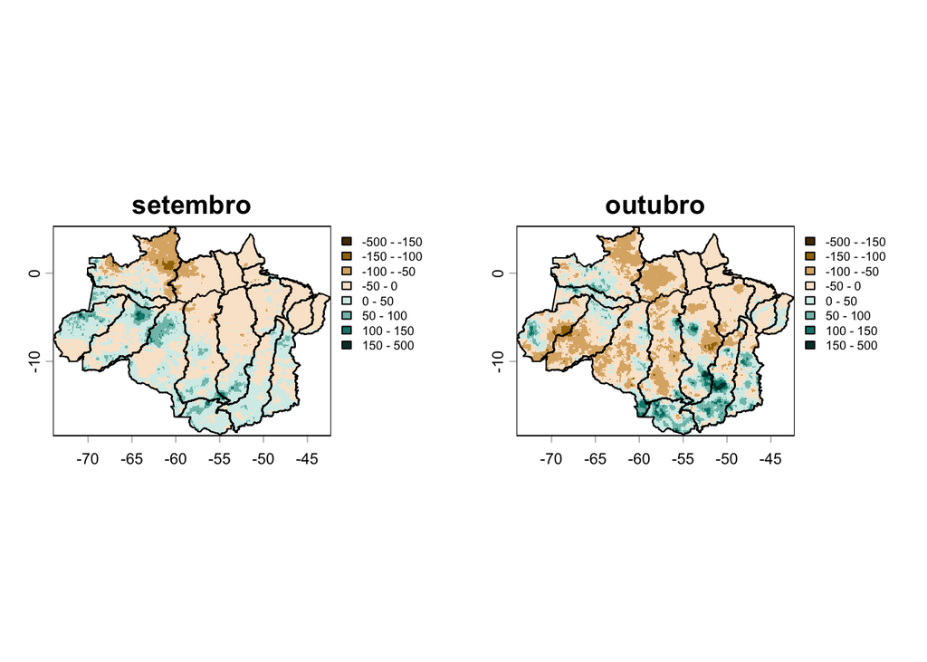

Figura 2: Anomalia de precipitação observada (mm) em bacias hidrográficas da Amazônia Legal, setembro e outubro de 2026

Tabela 3: Percentual do território dos estados da Amazônia Legal com anomalia de precipitação observada abaixo de 0mm e de -50mm.

| UF | setembro <0mm | setembro <-50mm | outubro <0mm | outubro <-50mm |
| --- | --- | --- | --- | --- |
| RR | 98% | 80% | 100% | 63% |
| AC | 72% | 0% | 82% | 49% |
| RO | 52% | 0% | 92% | 38% |
| AM | 47% | 7% | 68% | 22% |
| PA | 91% | 3% | 89% | 21% |
| MT | 29% | 0% | 42% | 12% |
| TO | 49% | 0% | 50% | 7% |
| MA | 79% | 0% | 77% | 3% |
| AP | 99% | 2% | 100% | 0% |

Tabela 4: Municípios da Amazônia Legal com anomalia de precipitação observada abaixo de -50mm, em percentual do território.

| Município | UF | setembro <0mm | setembro <-50mm | outubro <0mm | outubro <-50mm |
| --- | --- | --- | --- | --- | --- |
| Teixeirópolis | RO | 45% | 0% | 100% | 100% |
| Vale do Paraíso | RO | 74% | 0% | 100% | 100% |
| Santa Rosa do Purus | AC | 78% | 0% | 100% | 100% |
| Abaetetuba | PA | 100% | 0% | 100% | 100% |
| Ananindeua | PA | 100% | 0% | 100% | 100% |
| Benevides | PA | 100% | 0% | 100% | 100% |
| Marituba | PA | 100% | 0% | 100% | 100% |
| Carmolândia | TO | 0% | 0% | 100% | 100% |
| Itamarati | AM | 73% | 0% | 100% | 99% |
| Nova Maringá | MT | 27% | 0% | 100% | 96% |

[output cut: 303 more lines]

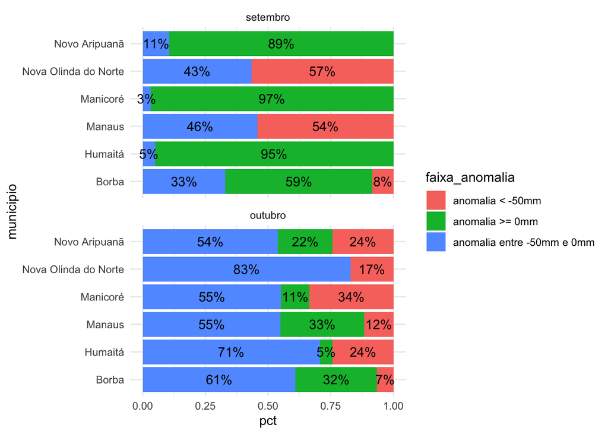

Figura 3: Anomalia de precipitação observada em Humaitá, Manicoré, Novo Aripuanã, Borba, Nova Olinda do Norte e Manaus, em proporção ao território, setembro e outubro de 2026

## Projeções (novembro e dezembro)

- 44,5% do território da Amazônia Legal deve ter anomalia de precipitação abaixo de -50mm em novembro, e 42,4% em dezembro. Chuva abaixo da média deve atingir 99,9% do território em novembro e 100,0% em dezembro (Tabela 5)
- Entre as bacias hidrográficas, as com maior parte do território abaixo de -50mm em novembro devem ser Alto Tocantins (100%), Trombetas/Uatumã (93%) e Xingu (91%); as com menor parte, Foz do Amazonas (0%), Javari/Juruá (0%) e Alto Paraguai (0%). Em dezembro, as com menor parte devem ser Javari/Juruá (0%) e Alto Paraguai (0%) (Tabela 6)
- Os estados com maior parte do território abaixo de -50mm em novembro devem ser TO (100%), PA (75%) e RR (72%); em dezembro, os com menor parte devem ser RO (0%) e AC (0%) (Tabela 7)
- 398 dos 809 municípios da Amazônia Legal devem ter alguma parte do território com anomalia abaixo de -50mm em novembro; em 344 deles, isso vale para mais da metade do território. Em dezembro, são 454 e 402, respectivamente (Tabela 8)
- Percentual do território com anomalia abaixo de -50mm nos municípios selecionados em novembro: Nova Olinda do Norte (100%), Manaus (99%), Borba (87%), Humaitá (50%), Novo Aripuanã (24%) e Manicoré (0%). Em dezembro: Manaus (100%), Nova Olinda do Norte (100%), Borba (71%), Manicoré (2%), Novo Aripuanã (1%) e Humaitá (0%) (Figura 5)

**Como as anomalias projetadas foram calculadas**

As anomalias projetadas foram fornecidas pelo Labclim a partir da previsão sazonal do ECMWF (rodada de outubro de 2026). A anomalia é calculada em relação à climatologia do próprio modelo, o que remove a tendência média do modelo de subestimar ou superestimar a chuva na região. A grade é de 1° (cerca de 110 km), e cada célula entra no cálculo com peso proporcional à área que cai dentro do território analisado. Com células desse tamanho, municípios pequenos ficam dentro de uma ou duas células, e o resultado reflete a média da região ao redor.

Tabela 5: Percentual do território da Amazônia Legal com anomalia de precipitação projetada abaixo de 0mm e de -50mm.

| Mês | Anomalia média | <0mm | <-50mm |
| --- | --- | --- | --- |
| novembro | -55,5mm | 99,9% | 44,5% |
| dezembro | -49,0mm | 100,0% | 42,4% |

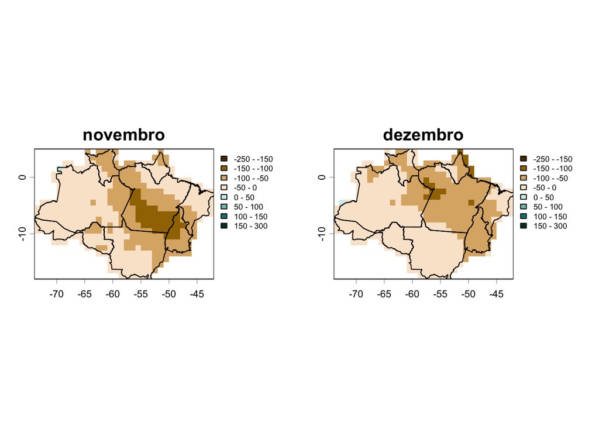

Figura 4: Anomalia de precipitação projetada (mm) na Amazônia Legal, novembro e dezembro de 2026

Tabela 6: Percentual do território das bacias hidrográficas da Amazônia Legal com anomalia de precipitação projetada abaixo de -50mm.

| Bacia | novembro <-50mm | dezembro <-50mm |
| --- | --- | --- |
| Alto Tocantins | 100% | 80% |
| Trombetas/Uatumã | 93% | 97% |
| Xingu | 91% | 65% |
| Araguaia | 89% | 61% |
| Tapajós | 73% | 40% |
| Baixo Tocantins | 52% | 100% |
| Oiapoque/Araguari | 35% | 80% |
| Madeira | 30% | 9% |
| Negro | 29% | 35% |
| Mearim | 24% | 62% |
| Paru/Jari | 8% | 51% |
| Itapecuru | 8% | 19% |
| Purus | 3% | 4% |
| Japurá | 1% | 8% |
| Gurupi | 1% | 68% |
| Foz do Amazonas | 0% | 91% |
| Javari/Juruá | 0% | 0% |
| Alto Paraguai | 0% | 0% |

Tabela 7: Percentual do território dos estados da Amazônia Legal com anomalia de precipitação projetada abaixo de -50mm.

| UF | novembro <-50mm | dezembro <-50mm |
| --- | --- | --- |
| TO | 100% | 100% |
| PA | 75% | 91% |
| RR | 72% | 60% |
| MT | 43% | 4% |
| RO | 33% | 0% |
| MA | 31% | 50% |
| AP | 21% | 63% |
| AM | 19% | 20% |
| AC | 0% | 0% |

Tabela 8: Municípios da Amazônia Legal com anomalia de precipitação projetada abaixo de -50mm, em percentual do território.

| Município | UF | novembro <-50mm | dezembro <-50mm |
| --- | --- | --- | --- |
| Rio Crespo | RO | 100% | 0% |
| Candeias do Jamari | RO | 100% | 0% |
| Cujubim | RO | 100% | 0% |
| Itapuã do Oeste | RO | 100% | 0% |
| Parecis | RO | 100% | 0% |
| Autazes | AM | 100% | 100% |
| Barreirinha | AM | 100% | 100% |
| Boa Vista do Ramos | AM | 100% | 100% |
| Careiro | AM | 100% | 100% |
| Careiro da Várzea | AM | 100% | 100% |

[output cut: 533 more lines]

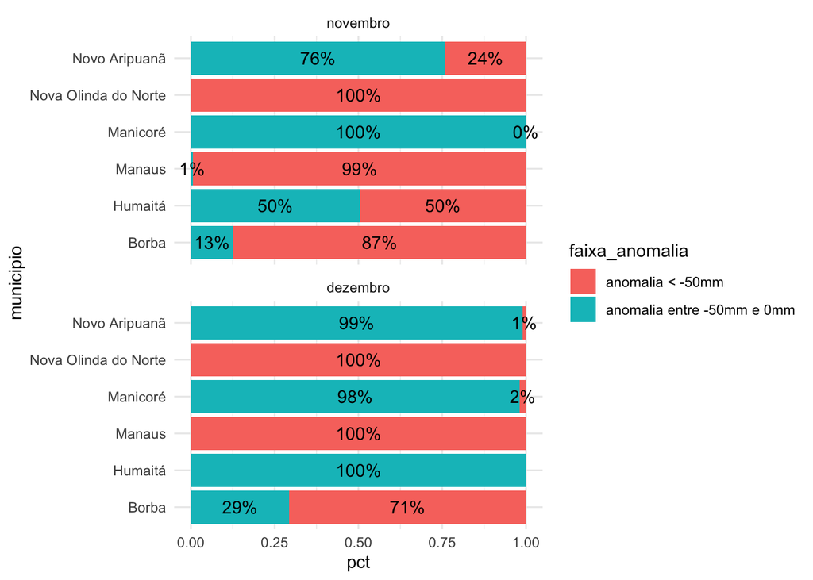

Figura 5: Anomalia de precipitação projetada em Humaitá, Manicoré, Novo Aripuanã, Borba, Nova Olinda do Norte e Manaus, em proporção ao território, novembro e dezembro de 2026

# Temperatura

## Dados observados (setembro e outubro)

- Em outubro, 67,8% do território da Amazônia Legal teve anomalia de temperatura acima de 1°C, e 17,8%, acima de 2°C. Em setembro, foram 15,0% e 4,9%, respectivamente (Tabela 9)
- Entre as bacias hidrográficas, as com maior parte do território acima de 1°C em outubro foram Trombetas/Uatumã (100%), Paru/Jari (100%) e Madeira (86%). Acima de 2°C, foram Trombetas/Uatumã (98%), Paru/Jari (46%) e Negro (32%). Em setembro, a bacia com maior parte do território acima de 1°C foi Trombetas/Uatumã (98%) (Tabela 10)
- Os estados com maior parte do território acima de 1°C em outubro foram RO (100%), RR (100%) e PA (86%). Acima de 2°C, foram RR (72%), RO (61%) e AC (31%) (Tabela 11)
- 544 dos 809 municípios da Amazônia Legal tiveram alguma parte do território com anomalia acima de 1°C em outubro, 421 deles em mais da metade do território. Acima de 2°C, foram 152 municípios, 85 deles em mais da metade do território. Em setembro, foram 157 municípios acima de 1°C (57 em mais da metade do território) e 44 acima de 2°C (18 em mais da metade do território) (Tabela 12)
- Anomalia média de temperatura em outubro nos municípios selecionados: Nova Olinda do Norte (2,1°C), Manaus (2,0°C), Borba (1,5°C), Novo Aripuanã (1,4°C), Humaitá (1,3°C) e Manicoré (1,1°C). Em setembro: Manaus (2,2°C), Nova Olinda do Norte (2,0°C), Borba (1,3°C), Novo Aripuanã (0,8°C), Manicoré (0,4°C) e Humaitá (0,0°C) (Tabela 13)

A anomalia observada vem do SAMeT (INPE), em grade de 0,05° (cerca de 5 km), e é a diferença entre a temperatura média do mês e a normal climatológica mensal do SAMeT. O cálculo segue o mesmo critério da precipitação observada: nos municípios, entram também as células que tocam o contorno.

Tabela 9: Percentual do território da Amazônia Legal com anomalia de temperatura observada acima de 1°C e de 2°C.

| Mês | Anomalia média | >1°C | >2°C |
| --- | --- | --- | --- |
| setembro | 0,3°C | 15,0% | 4,9% |
| outubro | 1,4°C | 67,8% | 17,8% |

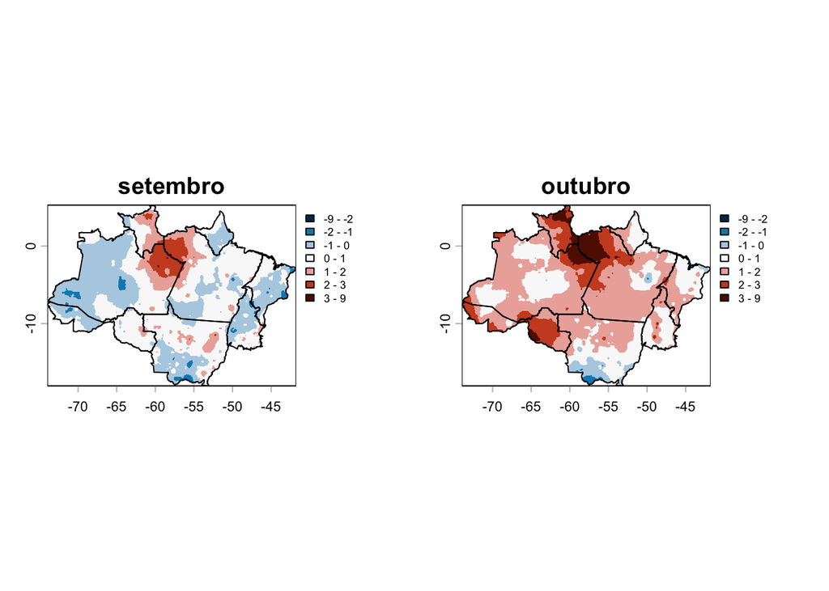

Figura 6: Anomalia de temperatura observada (°C) na Amazônia Legal, setembro e outubro de 2026

Tabela 10: Percentual do território das bacias hidrográficas da Amazônia Legal com anomalia de temperatura observada acima de 1°C e de 2°C.

| Bacia | setembro >1°C | setembro >2°C | outubro >1°C | outubro >2°C |
| --- | --- | --- | --- | --- |
| Trombetas/Uatumã | 98% | 65% | 100% | 98% |
| Paru/Jari | 17% | 0% | 100% | 46% |
| Madeira | 12% | 1% | 86% | 25% |
| Xingu | 8% | 0% | 85% | 4% |
| Negro | 28% | 5% | 78% | 32% |
| Tapajós | 23% | 5% | 77% | 19% |
| Japurá | 6% | 0% | 74% | 0% |
| Javari/Juruá | 0% | 0% | 66% | 12% |
| Purus | 0% | 0% | 63% | 9% |
| Baixo Tocantins | 1% | 0% | 60% | 2% |
| Gurupi | 3% | 0% | 44% | 7% |
| Foz do Amazonas | 0% | 0% | 40% | 2% |
| Alto Tocantins | 15% | 0% | 39% | 1% |
| Mearim | 0% | 0% | 38% | 0% |
| Itapecuru | 0% | 0% | 26% | 0% |
| Araguaia | 7% | 0% | 26% | 0% |
| Oiapoque/Araguari | 0% | 0% | 23% | 0% |
| Alto Paraguai | 1% | 0% | 0% | 0% |

Tabela 11: Percentual do território dos estados da Amazônia Legal com anomalia de temperatura observada acima de 1°C e de 2°C.

| UF | setembro >1°C | setembro >2°C | outubro >1°C | outubro >2°C |
| --- | --- | --- | --- | --- |
| RO | 5% | 0% | 100% | 61% |
| RR | 54% | 6% | 100% | 72% |
| PA | 21% | 7% | 86% | 26% |
| AC | 1% | 0% | 82% | 31% |
| AM | 17% | 9% | 70% | 13% |
| MA | 1% | 0% | 43% | 1% |
| MT | 10% | 0% | 43% | 0% |
| TO | 5% | 0% | 41% | 2% |
| AP | 0% | 0% | 41% | 0% |

Tabela 12: Municípios da Amazônia Legal com anomalia de temperatura observada acima de 1°C, em percentual do território.

| Município | UF | setembro >1°C | setembro >2°C | outubro >1°C | outubro >2°C |
| --- | --- | --- | --- | --- | --- |
| Ariquemes | RO | 0% | 0% | 100% | 100% |
| Costa Marques | RO | 0% | 0% | 100% | 100% |
| Guajará-Mirim | RO | 0% | 0% | 100% | 100% |
| Jaru | RO | 2% | 0% | 100% | 100% |
| Nova Brasilândia d'Oeste | RO | 0% | 0% | 100% | 100% |
| Ouro Preto do Oeste | RO | 42% | 0% | 100% | 100% |
| Presidente Médici | RO | 62% | 0% | 100% | 100% |
| Rio Crespo | RO | 0% | 0% | 100% | 100% |
| São Miguel do Guaporé | RO | 0% | 0% | 100% | 100% |
| Nova Mamoré | RO | 0% | 0% | 100% | 100% |

[output cut: 549 more lines]

Tabela 13: Anomalia de temperatura observada em Humaitá, Manicoré, Novo Aripuanã, Borba, Nova Olinda do Norte e Manaus.

| Município | Mês | Anomalia média | >1°C | >2°C |
| --- | --- | --- | --- | --- |
| Borba | setembro | 1,3°C | 72% | 2% |
| Borba | outubro | 1,5°C | 81% | 15% |
| Humaitá | setembro | 0,0°C | 0% | 0% |
| Humaitá | outubro | 1,3°C | 92% | 0% |
| Manaus | setembro | 2,2°C | 100% | 82% |
| Manaus | outubro | 2,0°C | 100% | 40% |
| Manicoré | setembro | 0,4°C | 0% | 0% |
| Manicoré | outubro | 1,1°C | 54% | 0% |
| Nova Olinda do Norte | setembro | 2,0°C | 100% | 57% |
| Nova Olinda do Norte | outubro | 2,1°C | 100% | 87% |
| Novo Aripuanã | setembro | 0,8°C | 17% | 0% |
| Novo Aripuanã | outubro | 1,4°C | 90% | 1% |

## Projeções (novembro e dezembro)

- 98,9% do território da Amazônia Legal deve ter anomalia de temperatura acima de 1°C em novembro, e 100,0% em dezembro. Acima de 2°C, são 70,4% e 70,2%, respectivamente (Tabela 14)
- Entre as bacias hidrográficas, as com maior parte do território acima de 2°C devem ser Xingu (100%), Tapajós (100%), Trombetas/Uatumã (100%), Araguaia (100%), Alto Tocantins (100%), Alto Paraguai (100%) e Paru/Jari (100%) em novembro e Xingu (100%), Trombetas/Uatumã (100%) e Alto Tocantins (100%) em dezembro. Acima de 1°C, a parte do território de cada bacia deve ser entre 76% e 100% em novembro e 100% em dezembro (Tabela 15)
- Os estados com maior parte do território acima de 2°C devem ser TO (100%), MT (100%) e RO (97%) em novembro e TO (100%), RR (97%) e PA (97%) em dezembro. Acima de 1°C, a parte do território de cada estado deve ser entre 88% e 100% em novembro e 100% em dezembro (Tabela 16)
- Em novembro, 777 dos 809 municípios da Amazônia Legal devem ter alguma parte do território com anomalia acima de 1°C (em 750, mais da metade do território); acima de 2°C, são 610 (564 com mais da metade do território). Em dezembro, são 809 municípios acima de 1°C (809 em mais da metade do território) e 683 acima de 2°C (625 em mais da metade do território) (Tabela 17)
- Anomalia média de temperatura projetada nos municípios selecionados em novembro: Nova Olinda do Norte (3,0°C), Borba (2,5°C), Manaus (2,4°C), Novo Aripuanã (2,3°C), Manicoré (2,2°C) e Humaitá (2,1°C). Em dezembro: Nova Olinda do Norte (2,7°C), Manaus (2,4°C), Borba (2,3°C), Novo Aripuanã (2,1°C), Manicoré (2,1°C) e Humaitá (2,0°C) (Tabela 18)

**Como as anomalias de temperatura projetadas foram calculadas**

A anomalia projetada é a anomalia da temperatura do ar a 2 metros na previsão sazonal do ECMWF (rodada de outubro de 2026), em relação à climatologia do próprio modelo, fornecida pelo Labclim. Valem as mesmas observações da precipitação: grade de 1° (cerca de 110 km), com cada célula pesando pela área que cai dentro do território analisado, o que suaviza diferenças locais e faz municípios pequenos refletirem a média da região ao redor.

Tabela 14: Percentual do território da Amazônia Legal com anomalia de temperatura projetada acima de 1°C e de 2°C.

| Mês | Anomalia média | >1°C | >2°C |
| --- | --- | --- | --- |
| novembro | 2,6°C | 98,9% | 70,4% |
| dezembro | 2,4°C | 100,0% | 70,2% |

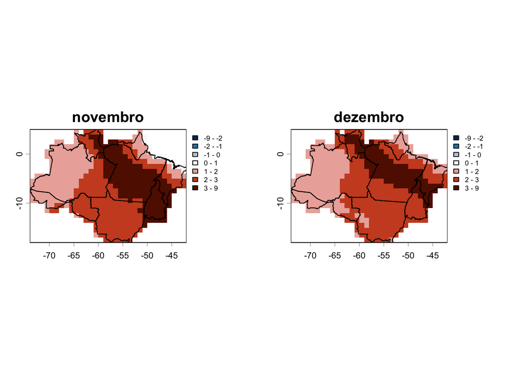

Figura 7: Anomalia de temperatura projetada (°C) na Amazônia Legal, novembro e dezembro de 2026

Tabela 15: Percentual do território das bacias hidrográficas da Amazônia Legal com anomalia de temperatura projetada acima de 1°C e de 2°C.

| Bacia | novembro >1°C | novembro >2°C | dezembro >1°C | dezembro >2°C |
| --- | --- | --- | --- | --- |
| Xingu | 100% | 100% | 100% | 100% |
| Paru/Jari | 100% | 100% | 100% | 98% |
| Tapajós | 100% | 100% | 100% | 93% |
| Trombetas/Uatumã | 100% | 100% | 100% | 100% |
| Javari/Juruá | 100% | 0% | 100% | 0% |
| Araguaia | 100% | 100% | 100% | 97% |
| Alto Tocantins | 100% | 100% | 100% | 100% |
| Negro | 100% | 38% | 100% | 50% |
| Madeira | 100% | 99% | 100% | 79% |
| Japurá | 100% | 8% | 100% | 10% |
| Purus | 100% | 24% | 100% | 14% |
| Alto Paraguai | 100% | 100% | 100% | 95% |
| Baixo Tocantins | 98% | 85% | 100% | 97% |
| Mearim | 97% | 74% | 100% | 91% |
| Oiapoque/Araguari | 96% | 6% | 100% | 25% |
| Foz do Amazonas | 95% | 24% | 100% | 70% |
| Itapecuru | 84% | 42% | 100% | 62% |
| Gurupi | 76% | 42% | 100% | 63% |

Tabela 16: Percentual do território dos estados da Amazônia Legal com anomalia de temperatura projetada acima de 1°C e de 2°C.

| UF | novembro >1°C | novembro >2°C | dezembro >1°C | dezembro >2°C |
| --- | --- | --- | --- | --- |
| RO | 100% | 97% | 100% | 52% |
| AC | 100% | 11% | 100% | 0% |
| AM | 100% | 35% | 100% | 36% |
| RR | 100% | 88% | 100% | 97% |
| TO | 100% | 100% | 100% | 100% |
| MT | 100% | 100% | 100% | 94% |
| PA | 99% | 92% | 100% | 97% |
| AP | 97% | 29% | 100% | 49% |
| MA | 88% | 65% | 100% | 80% |

Tabela 17: Municípios da Amazônia Legal com anomalia de temperatura projetada acima de 1°C, em percentual do território.

| Município | UF | novembro >1°C | novembro >2°C | dezembro >1°C | dezembro >2°C |
| --- | --- | --- | --- | --- | --- |
| Alta Floresta d'Oeste | RO | 100% | 100% | 100% | 91% |
| Ariquemes | RO | 100% | 100% | 100% | 93% |
| Cabixi | RO | 100% | 100% | 100% | 100% |
| Cacoal | RO | 100% | 100% | 100% | 100% |
| Cerejeiras | RO | 100% | 100% | 100% | 100% |
| Colorado do Oeste | RO | 100% | 100% | 100% | 96% |
| Corumbiara | RO | 100% | 100% | 100% | 78% |
| Espigão d'Oeste | RO | 100% | 100% | 100% | 100% |
| Jaru | RO | 100% | 100% | 100% | 94% |
| Ji-Paraná | RO | 100% | 100% | 100% | 98% |

[output cut: 799 more lines]

Tabela 18: Anomalia de temperatura projetada em Humaitá, Manicoré, Novo Aripuanã, Borba, Nova Olinda do Norte e Manaus.

| Município | Mês | Anomalia média | >1°C | >2°C |
| --- | --- | --- | --- | --- |
| Borba | novembro | 2,5°C | 100% | 100% |
| Borba | dezembro | 2,3°C | 100% | 100% |
| Humaitá | novembro | 2,1°C | 100% | 100% |
| Humaitá | dezembro | 2,0°C | 100% | 100% |
| Manaus | novembro | 2,4°C | 100% | 100% |
| Manaus | dezembro | 2,4°C | 100% | 100% |
| Manicoré | novembro | 2,2°C | 100% | 100% |
| Manicoré | dezembro | 2,1°C | 100% | 100% |
| Nova Olinda do Norte | novembro | 3,0°C | 100% | 100% |
| Nova Olinda do Norte | dezembro | 2,7°C | 100% | 100% |
| Novo Aripuanã | novembro | 2,3°C | 100% | 100% |
| Novo Aripuanã | dezembro | 2,1°C | 100% | 100% |